# Второе задание. Вариант 10. Заяц Артур.

```python
import numpy as np
import pandas as pd
import seaborn as sns
import scipy as sps
import matplotlib.pyplot as plt
from scipy.optimize import fsolve
from mpl_toolkits import mplot3d
from IPython.display import Image
sns.set_theme(style="whitegrid", palette="pastel")
```

# Задача 1

Используя систему компьютерной алгебры *[Wolfram Mathematica](https://www.wolfram.com/mathematica/)* решим систему в явном виде. Полученное решение запишем в виде функции.

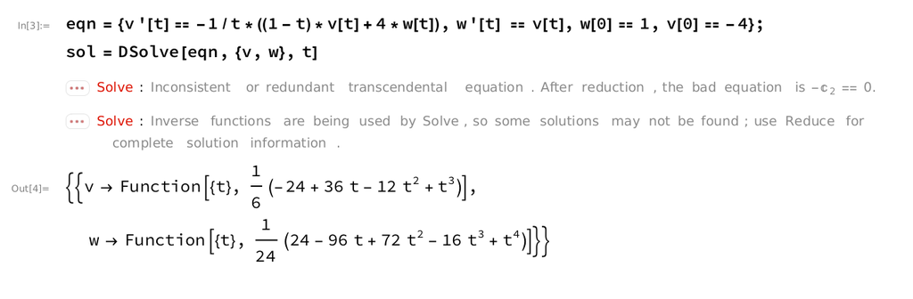

```python
Image("/home/stevejobs/Pictures/1.png")
```

```python
def solution(t):
    return np.array([1/6*(-24+36*t-12*t**2+t**3),1/24*(24-96*t+72*t**2-16*t**3+t**4)])
```

## Решение методом Эйлера

С начала реализуем **явный метод Эйлера** на отрезке [0,10] с нашими начальными условиями. Возможность изменять оставим только step

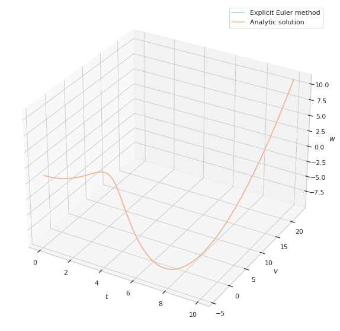

```python
def f(v,w,t): #Правая часть
    if t == 0: #Т.к. в нуле проблемы
        return np.array([0,-4])
    return np.array([-1/t*((1-t)*v+4*w),v])

step = 0.001 #Длина шага
time = np.array([i * step for i in range(int(10/step) + 1)]) #Наши шаги по времени

v_explicit, w_explicit = np.zeros(len(time)), np.zeros(len(time)) #Массив с ответами
v_explicit[0], w_explicit[0] = -4, 1 #Начальные условия

for i in range(1,len(time)): #Для каждого времени ищем ответ
    v_explicit[i] = step * f(v_explicit[i-1],w_explicit[i-1],time[i-1])[0] + v_explicit[i-1]
    w_explicit[i] = step * f(v_explicit[i-1],w_explicit[i-1],time[i-1])[1] + w_explicit[i-1]

solution_v = np.array([solution(i)[0] for i in time]) #Точные решения
solution_w = np.array([solution(i)[1] for i in time])

#Рисуем графики
plt.figure(figsize = (15,10))
ax = plt.axes(projection='3d')
ax.plot(time, v_explicit, w_explicit, label = 'Explicit Euler method')
ax.plot(time, solution_v, solution_w, label = 'Analytic solution')
ax.set_xlabel('$t$')
ax.set_ylabel('$v$')
ax.set_zlabel('$w$')
ax.legend();
```

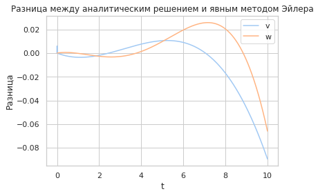

```python
plt.plot(time, solution_v-v_explicit,  label = 'v')
plt.plot(time, solution_w - w_explicit, label = 'w')
plt.title('Разница между аналитическим решением и явным методом Эйлера')
plt.xlabel('t')
plt.ylabel('Разница')
plt.legend();
```

Теперь посмотрим на **неявный метод Эйлера**. В данном случае $v^{k+1}$ и $w^{k+1}$ элементарно аналитически выражаются.

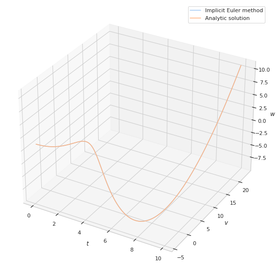

```python
def next_iter_v(v,w,t): #V_n+1 через v_n, w_n, t_n+1 полученно аналитически.
    return (v - step * 4 * w / t)/ (1 + (step * (1-t) + 4 * step ** 2)/ t )

def next_iter_w(v,w,t): #Аналогично w через v_n+1!
    return (w+step*v)


v_implicit, w_implicit = np.zeros(len(time)), np.zeros((len(time))) #Массив ответов
v_implicit[0], w_implicit[0] = -4, 1 #Начальные условия

for i in range(1,len(time)):
    v_implicit[i] = next_iter_v(v_implicit[i-1],w_implicit[i-1],time[i])
    w_implicit[i] = next_iter_w(v_implicit[i],w_implicit[i-1],time[i])

plt.figure(figsize = (15,10))
ax = plt.axes(projection='3d')
ax.plot(time, v_implicit, w_implicit, label = 'Implicit Euler method')
ax.plot(time, solution_v, solution_w, label = 'Analytic solution')
ax.set_xlabel('$t$')
ax.set_ylabel('$v$')
ax.set_zlabel('$w$')
ax.legend();
```

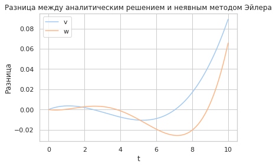

```python
plt.plot(time, solution_v-v_implicit,  label = 'v')
plt.plot(time, solution_w - w_implicit, label = 'w')
plt.title('Разница между аналитическим решением и неявным методом Эйлера')
plt.xlabel('t')
plt.ylabel('Разница')
plt.legend();
```

Теперь посмотрим на **метод Эйлера с центральной точкой**. Первое приближение возьмём из явного метода Эйлера.

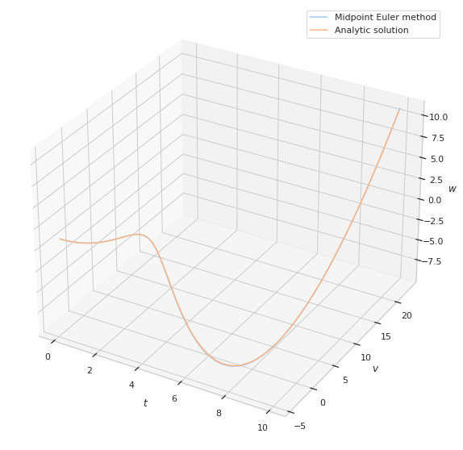

```python
v_central, w_central = np.zeros(len(time)), np.zeros(len(time)) #Массив ответов
v_central[0], w_central[0] = -4, 1 #Начальные условия
v_central[1], w_central[1] = v_explicit[1], w_explicit[1] #Первое возьмём из явного метода

for i in range(2, len(time)):
    v_central[i] = step * f(v_central[i-2], w_central[i-2], time[i-2])[0] + v_central[i-1]
    w_central[i] = step * f(v_central[i-2], w_central[i-2], time[i-2])[1] + w_central[i-1]



plt.figure(figsize = (15,10))
ax = plt.axes(projection='3d')
ax.plot(time, v_central, w_central, label = 'Midpoint Euler method')
ax.plot(time, solution_v, solution_w, label = 'Analytic solution')
ax.set_xlabel('$t$')
ax.set_ylabel('$v$')
ax.set_zlabel('$w$')
ax.legend();
```

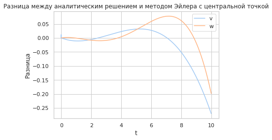

```python
plt.plot(time, solution_v-v_central,  label = 'v')
plt.plot(time, solution_w - w_central, label = 'w')
plt.title('Разница между аналитическим решением и методом Эйлера с центральной точкой')
plt.xlabel('t')
plt.ylabel('Разница')
plt.legend();
```

### Анализ

Шаг был выбран из соображений "достаточно маленький, но чтобы долго не считало". На практике, согласно, например, [данному источнику](https://elib.bsu.by/bitstream/123456789/1546/1/%D0%A4%D0%B0%D0%BB%D0%B5%D0%B9%D1%87%D0%B8%D0%BA.%20%D0%9E%D0%B4%D0%BD%D0%BE%D1%88%D0%B0%D0%B3%D0%BE%D0%B2%D1%8B%D0%B5%20%D0%BC%D0%B5%D1%82%D0%BE%D0%B4%D1%8B.pdf), он выбирается из требуемой точности, какой в условии задачи не было.

Вообще, для метода Рунге-Кутты произвольного порядка известно достаточное условие устойчивости: $c \cdot \tau \leq 1$, где $\tau$ - шаг интегрирования, $c$ - константа Липшица правой части уравнения. Для данной задачи, поиск\оценивание константы Липшица правой части - проблема, труднее всей задачи в целом. Исследовать на устойчивость с помощью фазовых траекторий - тоже непосильная задача, т.к. система неавтономна.

Так же важно отметить, что ни в курсе лекций, ни в "ближайшом интернете" не упоминается словосочетание "строго устойчивый метод". Было лишь найдено понятие $A$-устойчивого метода.

Согласно [литературе](http://qilab.phys.msu.ru/people/zadkov/teaching/seminar1/semnumer3.pdf#page=6), явный метод Эйлера является $A$ устойчивым на отрезке [0,2], а неявный - на всем вещественном интервале, кроме данного отрезка.

## Решение методом Рунге-Кутты

Согласно [литературе](http://www.mathnet.ru/links/a4cbea9f54090c09a0a20a14bbed97e9/zvmmf167.pdf), наименьшая погрешность двухстадийного метода Рунге-Кутты достигается при следующих параметрах.

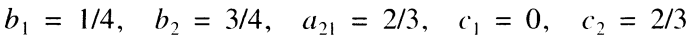

Данная информация была получена в процессе подготовки к самостоятельной реализации.

Однако,реализовывать самому такое не обязательно, даже избыточно. Библиотка *[scipy](https://docs.scipy.org/doc/scipy/index.html)* имеет свою готовую реализацию. Для решения будем использовать [следующую](https://docs.scipy.org/doc/scipy/reference/generated/scipy.integrate.solve_ivp.html#r179348322575-3) функцию. Один из главных параметров - rtol, т.е. мы сами можем контроллировать **точность** полученного **решения**. Данный метод имеет встроенный алгоритм автоматического выбора шага.

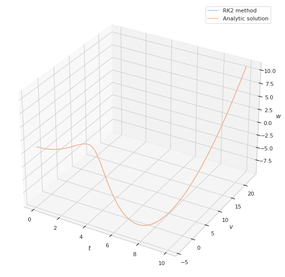

```python
def func(t,y): #Определим функцию так, чтобы scipy мог с ей работать
    if t == 0:
        return np.array([0,-4])
    else:
        return np.array([-1/t*((1-t)*y[0]+4*y[1]),y[0]])

y_rk = sps.integrate.solve_ivp(func, (0,10), rtol = 0.00001, y0 = np.array([-4,1]), method = 'RK23')

plt.figure(figsize = (15,10))
ax = plt.axes(projection='3d')
ax.plot(y_rk['t'], y_rk['y'][0], y_rk['y'][1], label = 'RK2 method')
ax.plot(time, solution_v, solution_w, label = 'Analytic solution')
ax.set_xlabel('$t$')
ax.set_ylabel('$v$')
ax.set_zlabel('$w$')
ax.legend();
```

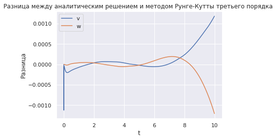

```python
solution_v, solution_w = [solution(t)[0] for t in y_rk['t']], [solution(t)[1] for t in y_rk['t']]
plt.plot(y_rk['t'], y_rk['y'][0] - solution_v, label = 'v')
plt.plot(y_rk['t'], solution_w -  y_rk['y'][1], label = 'w')
plt.title('Разница между аналитическим решением и методом Рунге-Кутты третьего порядка ')
plt.xlabel('t')
plt.ylabel('Разница')
plt.legend();
```

Но требуется проверить работу метода второго порядка. Будем использовать метод *[NSolve](https://reference.wolfram.com/language/ref/NDSolve.html)* из *Wolfram Mathematica*. Т.к. в отличии от *Python*, в этой системе нельзя задать функцию, самостоятельно её доопределив в нуле, возьмём решение метода Эйлера на 10 шаге и будем решать задачу Коши с полученной точке на интервале времени [0.01,10]. Один из параметров функции - количество правильных знаков после запятой.

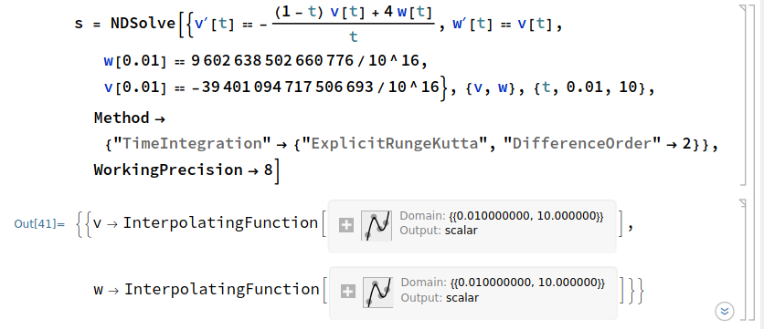

Посмотрим на разницу с точным решением(по оси x - время, y - разница):

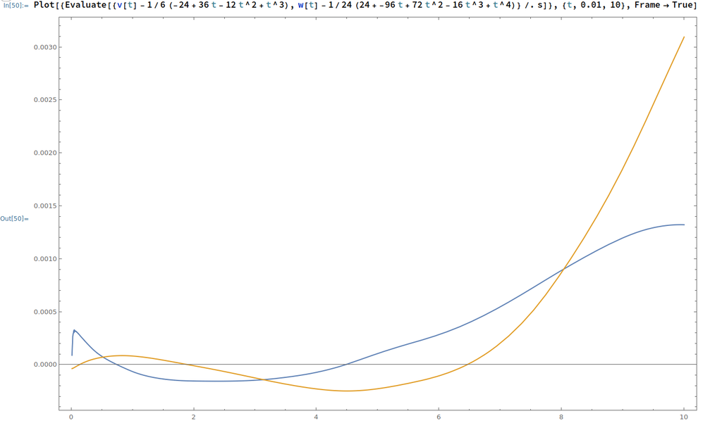

#### Выводы

Как видно, все методы показывают достаточно большую точность, сравнивать попарно их не имеет смысла. Также не имеет смысла искать оптимальный метод для этой задачи, в таком случае стоило бы делать поиск по более широкому классу методов.